# Exploratory Data Analysis using the Top 50 Spotify Songs

Taylor Saunders DAT301 Fall 2023

## Introduction

This report displays an Exploratory Data Analysis of the top 50 spotify songs in 2019

Data set sourced from Kaggle: https://www.kaggle.com/datasets/leonardopena/top50spotify2019/data

### What is Spotify?

Spotify is a music streaming platform that was established in 2006. Since then, spotify has grown to a size of about 489 million users. Due to the platforms popularity, it is a good tool to view what songs/artists are popular world wide and to analyze music trends.

#### Beginning with the Data

First, I am loading in the libraries I will be using for analysis and visualization.

```python
import numpy as np
import pandas as pd
#To visualize the data
import matplotlib.pyplot as plt
import seaborn as sns
import warnings
warnings.filterwarnings('ignore') #supress warning messages packages may produce
```

Next, to begin our data anaylsis I loaded in the spreadsheet containing the information about the top 50 songs on spotify. The dataset will be referred to as "mydf" for the duration of this report.

```python
mydf = pd.read_csv("top50spotifyutf.csv")
```

## Data Cleaning

The first step to a successful exploratory data analysis is data cleaning. This ensures that the numbers we produce in our report are accurate and relevant to the reality of the data presented.

The first step I will perform is to remove any NA values that may be present.

```python
mydf.dropna()
```

|  | Unnamed: 0 | Track.Name | Artist.Name | Genre | Beats.Per.Minute | Energy | Danceability | Loudness..dB.. | Liveness | Valence. | Length. | Acousticness.. | Speechiness. | Popularity |
| --- | --- | --- | --- | --- | --- | --- | --- | --- | --- | --- | --- | --- | --- | --- |
| 0 | 1 | Señorita | Shawn Mendes | canadian pop | 117 | 55 | 76 | -6 | 8 | 75 | 191 | 4 | 3 | 79 |
| 1 | 2 | China | Anuel AA | reggaeton flow | 105 | 81 | 79 | -4 | 8 | 61 | 302 | 8 | 9 | 92 |
| 2 | 3 | boyfriend (with Social House) | Ariana Grande | dance pop | 190 | 80 | 40 | -4 | 16 | 70 | 186 | 12 | 46 | 85 |
| 3 | 4 | Beautiful People (feat. Khalid) | Ed Sheeran | pop | 93 | 65 | 64 | -8 | 8 | 55 | 198 | 12 | 19 | 86 |
| 4 | 5 | Goodbyes (Feat. Young Thug) | Post Malone | dfw rap | 150 | 65 | 58 | -4 | 11 | 18 | 175 | 45 | 7 | 94 |
| 5 | 6 | I Don't Care (with Justin Bieber) | Ed Sheeran | pop | 102 | 68 | 80 | -5 | 9 | 84 | 220 | 9 | 4 | 84 |
| 6 | 7 | Ransom | Lil Tecca | trap music | 180 | 64 | 75 | -6 | 7 | 23 | 131 | 2 | 29 | 92 |
| 7 | 8 | How Do You Sleep? | Sam Smith | pop | 111 | 68 | 48 | -5 | 8 | 35 | 202 | 15 | 9 | 90 |
| 8 | 9 | Old Town Road - Remix | Lil Nas X | country rap | 136 | 62 | 88 | -6 | 11 | 64 | 157 | 5 | 10 | 87 |
| 9 | 10 | bad guy | Billie Eilish | electropop | 135 | 43 | 70 | -11 | 10 | 56 | 194 | 33 | 38 | 95 |
| 10 | 11 | Callaita | Bad Bunny | reggaeton | 176 | 62 | 61 | -5 | 24 | 24 | 251 | 60 | 31 | 93 |
| 11 | 12 | Loco Contigo (feat. J. Balvin & Tyga) | DJ Snake | dance pop | 96 | 71 | 82 | -4 | 15 | 38 | 185 | 28 | 7 | 86 |
| 12 | 13 | Someone You Loved | Lewis Capaldi | pop | 110 | 41 | 50 | -6 | 11 | 45 | 182 | 75 | 3 | 88 |
| 13 | 14 | Otro Trago - Remix | Sech | panamanian pop | 176 | 79 | 73 | -2 | 6 | 76 | 288 | 7 | 20 | 87 |
| 14 | 15 | Money In The Grave (Drake ft. Rick Ross) | Drake | canadian hip hop | 101 | 50 | 83 | -4 | 12 | 10 | 205 | 10 | 5 | 92 |
| 15 | 16 | No Guidance (feat. Drake) | Chris Brown | dance pop | 93 | 45 | 70 | -7 | 16 | 14 | 261 | 12 | 15 | 82 |
| 16 | 17 | LA CANCIÓN | J Balvin | latin | 176 | 65 | 75 | -6 | 11 | 43 | 243 | 15 | 32 | 90 |
| 17 | 18 | Sunflower - Spider-Man: Into the Spider-Verse | Post Malone | dfw rap | 90 | 48 | 76 | -6 | 7 | 91 | 158 | 56 | 5 | 91 |
| 18 | 19 | Lalala | Y2K | canadian hip hop | 130 | 39 | 84 | -8 | 14 | 50 | 161 | 18 | 8 | 88 |
| 19 | 20 | Truth Hurts | Lizzo | escape room | 158 | 62 | 72 | -3 | 12 | 41 | 173 | 11 | 11 | 91 |
| 20 | 21 | Piece Of Your Heart | MEDUZA | pop house | 124 | 74 | 68 | -7 | 7 | 63 | 153 | 4 | 3 | 91 |
| 21 | 22 | Panini | Lil Nas X | country rap | 154 | 59 | 70 | -6 | 12 | 48 | 115 | 34 | 8 | 91 |
| 22 | 23 | No Me Conoce - Remix | Jhay Cortez | reggaeton flow | 92 | 79 | 81 | -4 | 9 | 58 | 309 | 14 | 7 | 83 |
| 23 | 24 | Soltera - Remix | Lunay | latin | 92 | 78 | 80 | -4 | 44 | 80 | 266 | 36 | 4 | 91 |
| 24 | 25 | bad guy (with Justin Bieber) | Billie Eilish | electropop | 135 | 45 | 67 | -11 | 12 | 68 | 195 | 25 | 30 | 89 |
| 25 | 26 | If I Can't Have You | Shawn Mendes | canadian pop | 124 | 82 | 69 | -4 | 13 | 87 | 191 | 49 | 6 | 70 |
| 26 | 27 | Dance Monkey | Tones and I | australian pop | 98 | 59 | 82 | -6 | 18 | 54 | 210 | 69 | 10 | 83 |
| 27 | 28 | It's You | Ali Gatie | canadian hip hop | 96 | 46 | 73 | -7 | 19 | 40 | 213 | 37 | 3 | 89 |
| 28 | 29 | Con Calma | Daddy Yankee | latin | 94 | 86 | 74 | -3 | 6 | 66 | 193 | 11 | 6 | 91 |
| 29 | 30 | QUE PRETENDES | J Balvin | latin | 93 | 79 | 64 | -4 | 36 | 94 | 222 | 3 | 25 | 89 |
| 30 | 31 | Takeaway | The Chainsmokers | edm | 85 | 51 | 29 | -8 | 10 | 36 | 210 | 12 | 4 | 84 |
| 31 | 32 | 7 rings | Ariana Grande | dance pop | 140 | 32 | 78 | -11 | 9 | 33 | 179 | 59 | 33 | 89 |
| 32 | 33 | 0.958333333 | Maluma | reggaeton | 96 | 71 | 78 | -5 | 9 | 68 | 176 | 22 | 28 | 89 |
| 33 | 34 | The London (feat. J. Cole & Travis Scott) | Young Thug | atl hip hop | 98 | 59 | 80 | -7 | 13 | 18 | 200 | 2 | 15 | 89 |
| 34 | 35 | Never Really Over | Katy Perry | dance pop | 100 | 88 | 77 | -5 | 32 | 39 | 224 | 19 | 6 | 89 |
| 35 | 36 | Summer Days (feat. Macklemore & Patrick Stump ... | Martin Garrix | big room | 114 | 72 | 66 | -7 | 14 | 32 | 164 | 18 | 6 | 89 |
| 36 | 37 | Otro Trago | Sech | panamanian pop | 176 | 70 | 75 | -5 | 11 | 62 | 226 | 14 | 34 | 91 |
| 37 | 38 | Antisocial (with Travis Scott) | Ed Sheeran | pop | 152 | 82 | 72 | -5 | 36 | 91 | 162 | 13 | 5 | 87 |
| 38 | 39 | Sucker | Jonas Brothers | boy band | 138 | 73 | 84 | -5 | 11 | 95 | 181 | 4 | 6 | 80 |
| 39 | 40 | fuck, i'm lonely (with Anne-Marie) - from “13 ... | Lauv | dance pop | 95 | 56 | 81 | -6 | 6 | 68 | 199 | 48 | 7 | 78 |
| 40 | 41 | Higher Love | Kygo | edm | 104 | 68 | 69 | -7 | 10 | 40 | 228 | 2 | 3 | 88 |
| 41 | 42 | You Need To Calm Down | Taylor Swift | dance pop | 85 | 68 | 77 | -6 | 7 | 73 | 171 | 1 | 5 | 90 |
| 42 | 43 | Shallow | Lady Gaga | dance pop | 96 | 39 | 57 | -6 | 23 | 32 | 216 | 37 | 3 | 87 |
| 43 | 44 | Talk | Khalid | pop | 136 | 40 | 90 | -9 | 6 | 35 | 198 | 5 | 13 | 84 |
| 44 | 45 | Con Altura | ROSALÍA | r&b en espanol | 98 | 69 | 88 | -4 | 5 | 75 | 162 | 39 | 12 | 88 |
| 45 | 46 | One Thing Right | Marshmello | brostep | 88 | 62 | 66 | -2 | 58 | 44 | 182 | 7 | 5 | 88 |
| 46 | 47 | Te Robaré | Nicky Jam | latin | 176 | 75 | 67 | -4 | 8 | 80 | 202 | 24 | 6 | 88 |
| 47 | 48 | Happier | Marshmello | brostep | 100 | 79 | 69 | -3 | 17 | 67 | 214 | 19 | 5 | 88 |
| 48 | 49 | Call You Mine | The Chainsmokers | edm | 104 | 70 | 59 | -6 | 41 | 50 | 218 | 23 | 3 | 88 |
| 49 | 50 | Cross Me (feat. Chance the Rapper & PnB Rock) | Ed Sheeran | pop | 95 | 79 | 75 | -6 | 7 | 61 | 206 | 21 | 12 | 82 |

```python
mydf.shape
```

```
(50, 14)
```

As we can see, we still have 50 rows of data. Therefore, there were no NA values in our dataset.

To further our analysis, I will begin to get us comfortable with the data by performing various steps to determine classes we are dealing with and an idea of what kind of genres are in our dataset.

```python
mydf.head()
```

|  | Unnamed: 0 | Track.Name | Artist.Name | Genre | Beats.Per.Minute | Energy | Danceability | Loudness..dB.. | Liveness | Valence. | Length. | Acousticness.. | Speechiness. | Popularity |
| --- | --- | --- | --- | --- | --- | --- | --- | --- | --- | --- | --- | --- | --- | --- |
| 0 | 1 | Señorita | Shawn Mendes | canadian pop | 117 | 55 | 76 | -6 | 8 | 75 | 191 | 4 | 3 | 79 |
| 1 | 2 | China | Anuel AA | reggaeton flow | 105 | 81 | 79 | -4 | 8 | 61 | 302 | 8 | 9 | 92 |
| 2 | 3 | boyfriend (with Social House) | Ariana Grande | dance pop | 190 | 80 | 40 | -4 | 16 | 70 | 186 | 12 | 46 | 85 |
| 3 | 4 | Beautiful People (feat. Khalid) | Ed Sheeran | pop | 93 | 65 | 64 | -8 | 8 | 55 | 198 | 12 | 19 | 86 |
| 4 | 5 | Goodbyes (Feat. Young Thug) | Post Malone | dfw rap | 150 | 65 | 58 | -4 | 11 | 18 | 175 | 45 | 7 | 94 |

```python
mydf.tail()
```

|  | Unnamed: 0 | Track.Name | Artist.Name | Genre | Beats.Per.Minute | Energy | Danceability | Loudness..dB.. | Liveness | Valence. | Length. | Acousticness.. | Speechiness. | Popularity |
| --- | --- | --- | --- | --- | --- | --- | --- | --- | --- | --- | --- | --- | --- | --- |
| 45 | 46 | One Thing Right | Marshmello | brostep | 88 | 62 | 66 | -2 | 58 | 44 | 182 | 7 | 5 | 88 |
| 46 | 47 | Te Robaré | Nicky Jam | latin | 176 | 75 | 67 | -4 | 8 | 80 | 202 | 24 | 6 | 88 |
| 47 | 48 | Happier | Marshmello | brostep | 100 | 79 | 69 | -3 | 17 | 67 | 214 | 19 | 5 | 88 |
| 48 | 49 | Call You Mine | The Chainsmokers | edm | 104 | 70 | 59 | -6 | 41 | 50 | 218 | 23 | 3 | 88 |
| 49 | 50 | Cross Me (feat. Chance the Rapper & PnB Rock) | Ed Sheeran | pop | 95 | 79 | 75 | -6 | 7 | 61 | 206 | 21 | 12 | 82 |

As we can see, the columns we are dealing with are:

Genre

Beats per Minute

Energy

Danceability

Loudness (dB)

Liveness

Valence

Length

Acousticness

Speechiness

Popularity

These are all unique values that will help us determine correlation between the top 50 songs.

```python
mydf.info()
```

```
<class 'pandas.core.frame.DataFrame'>
RangeIndex: 50 entries, 0 to 49
Data columns (total 14 columns):
 #   Column            Non-Null Count  Dtype
---  ------            --------------  -----
 0   Unnamed: 0        50 non-null     int64
 1   Track.Name        50 non-null     object
 2   Artist.Name       50 non-null     object
 3   Genre             50 non-null     object
 4   Beats.Per.Minute  50 non-null     int64
 5   Energy            50 non-null     int64
 6   Danceability      50 non-null     int64
 7   Loudness..dB..    50 non-null     int64
 8   Liveness          50 non-null     int64
 9   Valence.          50 non-null     int64
 10  Length.           50 non-null     int64
 11  Acousticness..    50 non-null     int64
 12  Speechiness.      50 non-null     int64
 13  Popularity        50 non-null     int64
dtypes: int64(11), object(3)
memory usage: 5.6+ KB
```

The two types of variables we are dealing with are objects and integers.

## Data Analysis

```python
mydf.describe()
```

|  | Unnamed: 0 | Beats.Per.Minute | Energy | Danceability | Loudness..dB.. | Liveness | Valence. | Length. | Acousticness.. | Speechiness. | Popularity |
| --- | --- | --- | --- | --- | --- | --- | --- | --- | --- | --- | --- |
| count | 50.00000 | 50.000000 | 50.000000 | 50.00000 | 50.000000 | 50.000000 | 50.000000 | 50.000000 | 50.000000 | 50.000000 | 50.000000 |
| mean | 25.50000 | 120.060000 | 64.060000 | 71.38000 | -5.660000 | 14.660000 | 54.600000 | 200.960000 | 22.160000 | 12.480000 | 87.500000 |
| std | 14.57738 | 30.898392 | 14.231913 | 11.92988 | 2.056448 | 11.118306 | 22.336024 | 39.143879 | 18.995553 | 11.161596 | 4.491489 |
| min | 1.00000 | 85.000000 | 32.000000 | 29.00000 | -11.000000 | 5.000000 | 10.000000 | 115.000000 | 1.000000 | 3.000000 | 70.000000 |
| 25% | 13.25000 | 96.000000 | 55.250000 | 67.00000 | -6.750000 | 8.000000 | 38.250000 | 176.750000 | 8.250000 | 5.000000 | 86.000000 |
| 50% | 25.50000 | 104.500000 | 66.500000 | 73.50000 | -6.000000 | 11.000000 | 55.500000 | 198.000000 | 15.000000 | 7.000000 | 88.000000 |
| 75% | 37.75000 | 137.500000 | 74.750000 | 79.75000 | -4.000000 | 15.750000 | 69.500000 | 217.500000 | 33.750000 | 15.000000 | 90.750000 |
| max | 50.00000 | 190.000000 | 88.000000 | 90.00000 | -2.000000 | 58.000000 | 95.000000 | 309.000000 | 75.000000 | 46.000000 | 95.000000 |

```python
mydf['Genre'].value_counts()
```

```
dance pop           8
pop                 7
latin               5
edm                 3
canadian hip hop    3
reggaeton           2
reggaeton flow      2
panamanian pop      2
dfw rap             2
brostep             2
country rap         2
electropop          2
canadian pop        2
boy band            1
pop house           1
trap music          1
atl hip hop         1
australian pop      1
escape room         1
r&b en espanol      1
big room            1
Name: Genre, dtype: int64
```

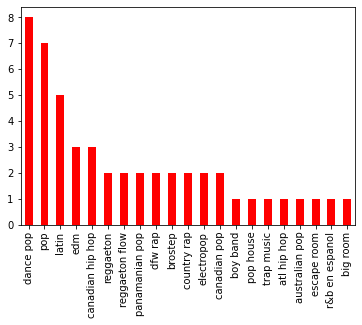

```python
plt.figure()
mydf['Genre'].value_counts().plot(kind = 'bar', color = 'r')
```

The most common genre is dance pop, closely followed by pop.

```python
mydf['Artist.Name'].value_counts()
```

```
Ed Sheeran          4
J Balvin            2
The Chainsmokers    2
Ariana Grande       2
Marshmello          2
Lil Nas X           2
Billie Eilish       2
Shawn Mendes        2
Sech                2
Post Malone         2
Maluma              1
Katy Perry          1
Bad Bunny           1
Drake               1
DJ Snake            1
Lizzo               1
Martin Garrix       1
Young Thug          1
Taylor Swift        1
Sam Smith           1
Lewis Capaldi       1
Lauv                1
Y2K                 1
Ali Gatie           1
Daddy Yankee        1
Jhay Cortez         1
Jonas Brothers      1
Tones and I         1
Lunay               1
Lady Gaga           1
Chris Brown         1
ROSALÍA             1
MEDUZA              1
Kygo                1
Khalid              1
Nicky Jam           1
Lil Tecca           1
Anuel AA            1
Name: Artist.Name, dtype: int64
```

Ed Sheeran had the most popular songs, amounting to 4 out of the 50 top songs.

## Data Visualization

Now, lets begin to visualize our data to derive conclusions to the following research questions:

```
1. Is there a connection betweeen danceability and popularity?
2. What music genre was the most popular in 2019 on Spotify?
3. What is the correlation between danceability and pop genres
```

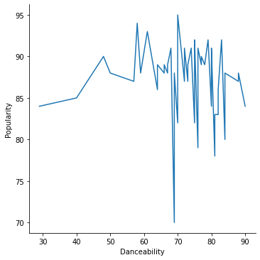

```python
sns.relplot(
    data=mydf, kind="line",
    x="Danceability", y="Popularity",
    estimator=None,
)
```

There does not appear to be a clear correlation between danceability and popularity based on this graph.

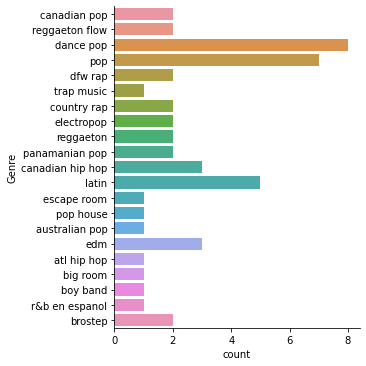

```python
sns.catplot(data= mydf, y='Genre', kind= 'count')
```

Based on this plot, we can see the most popular genres are dance pop and pop. Because of this analysis, it feeds into the next question:

What is the correlation between pop genres and danceability?

```python
for i in mydf['Genre']:
    if 'pop' in i:
        mydf['Genre'] = mydf['Genre'].replace(i, 'pop')
```

```python
mydf['Genre'].unique()
```

```
array(['pop', 'reggaeton flow', 'dfw rap', 'trap music', 'country rap',
       'reggaeton', 'canadian hip hop', 'latin', 'escape room', 'edm',
       'atl hip hop', 'big room', 'boy band', 'r&b en espanol', 'brostep'],
      dtype=object)
```

After grouping all genres including "pop", we can begin simple visualization.

```python
mypopdf = mydf[mydf['Genre'] == 'pop']
```

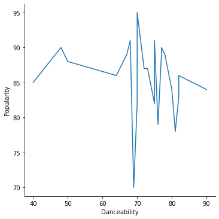

```python
sns.relplot(
    data=mypopdf, kind="line",
    x="Danceability", y="Popularity",
    estimator=None,
)
```

This looks very similar to our plot above. Lets try a different kind of plot to see if we can get a clearer result.

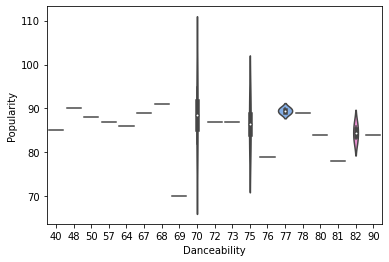

```python
sns.violinplot(x='Danceability', y='Popularity', data=mypopdf)
plt.show()
```

This isnt very clear either - lets try one more!

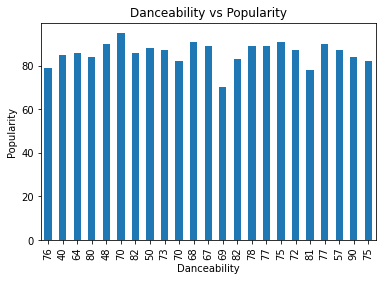

```python
mypopdf.plot(kind='bar', x='Danceability', y='Popularity', legend=False)
plt.title('Danceability vs Popularity')
plt.xlabel('Danceability')
plt.ylabel('Popularity')
plt.show()
```

After three tests, I have come to the conclusion that danceability has no correlation to popularity for either pop-specific songs or all genres in this dataframe.

## Conclusion

Based on my research, I concluded that danceability does not affect popularity (in the top 50 songs) and pop genres are the most popular genre. Additionally, there is a wide variety of genres and artists in the top 50; the artist with the most songs in top 50 (Ed Sheernan) only amounts to 4 of the songs. This suggests users of Spotify are very diverse, and more research could be done using music statistics from spotify as music is an interesting demographic that may correlate to different backgrounds.

#### Possible Future Work

Further analysis can be done to determine what popular artists are doing to succeed on Spotify's platform, and it could be replecated by smaller bands to determine if replicating beats per minute and dB levels can create higher desire for music.